# Demo: phyloseq – A Bioconductor package for handling and analysis of high-throughput phylogenetic sequence data

Paul J. McMurdie and Susan Holmes  
Statistics Department, Stanford University,  
Stanford, CA 94305, USA

```
E-mail: mcmurdie@stanford.edu
https://github.com/joey711/phyloseq
susan@stat.stanford.edu\
http://www-stat.stanford.edu/~susan/
```

## Summary

This is a demonstration manual for the phyloseq package. It is a Sweave  
source-file with example code-chunks that can be reused if you have  
phyloseq installed.

## About this demo

Vignettes are included in phyloseq. A quick way to load them from within `R` is:

```r
vignette("phyloseqbasics")
vignette("phyloseqanalysis")
```

This demonstration document supports a live demonstration of tools in  
phyloseq, and supplements other documentation resources  
available for [the phyloseq package](https://github.com/joey711/phyloseq) (e.g. wiki, vignettes, publications, function-level documentation, etc.).

Let’s start by loading the phyloseq-package:

```r
library("phyloseq")
```

```r
library("ggplot2")
```

And because we will show examples of custom modifications to ggplot2  
plots, we also loaded [the ggplot2 package](http://had.co.nz/ggplot2/) as well.

## Data

To facilitate testing and exploration of tools in phyloseq,  
this package includes example data from published studies. Many of the  
examples in this vignette use either the GlobalPatterns or enterotype  
datasets as source data. The GlobalPatterns data was described in an  
article in PNAS in 2011 \cite{Caporaso15032011}, and compares the  
microbial communities of 25 environmental samples and three known “mock  
communities” — a total of 9 sample types — at a depth averaging 3.1  
million reads per sample. The enterotype dataset was described in a 2011  
article in Nature \cite{Arumugam:2011fk}, which compares, the faecal  
microbial communities from 22 subjects using complete shotgun DNA  
sequencing. The authors further compare these microbial communities with  
the faecal communities of subjects from other studies, for a total of  
280 faecal samples / subjects, and 553 genera. Sourcing data from  
different studies invariable leads to gaps in the data for certain  
variables, and this is easily handled by R’s core NA features.

Because this data is included in the package, the examples can easily be  
run on your own computer using the code shown in this vignette. The data  
is loaded into memory using the data command. Let’s start by loading the  
GlobalPatterns data.

Later on we will use an additional categorical designation — human  
versus non-human associated samples — that was not in the original  
dataset. Now is a good time to add it as an explicit variable of the  
sampleData, and because we don’t want to type long words over and over,  
we’ll choose a shorter name for this modified version of GlobalPatterns,  
call it GP, and also remove a handful of taxa that are not present in  
any of the samples included in this dataset (probably an artifact):

```r
data(GlobalPatterns)
# prune OTUs that are not present in at least one sample
GP <- prune_species(speciesSums(GlobalPatterns) > 0, GlobalPatterns)
# Define a human-associated versus non-human categorical variable:
sampleData(GP)$human <- factor(getVariable(GP, "SampleType") %in%
    c("Feces", "Mock", "Skin", "Tongue"))
```

# Simple exploratory graphics

## Easy Richness Estimates

We can easily create a complex graphic that compares the richness  
estimates of samples from different environment types in the  
GlobalPatterns dataset, using the plot_richness_estimates function.  
Note that it is important to use raw (untrimmed) OTU-clustered data when  
performing richness estimates, as they are highly dependent on the  
number of singletons in a sample.

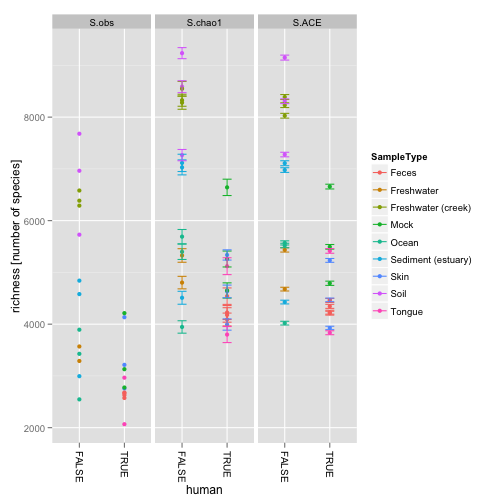

```r
p <- plot_richness_estimates(GP, "human", "SampleType")
print(p)
```

Adding an extra layer with the boxplot geometric object, using the ggplot2 function `geom_boxplot`, groups the y-values for the same horizontal position and color (shape, etc.). For example

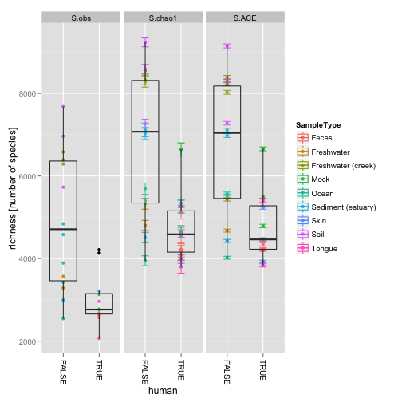

```r
(p <- p + geom_boxplot(data = p$data, aes(x = human, y = value, color = NULL),
    alpha = 0.1))
```

<sub><sup>Estimates of the species richness of samples in the “Global Patterns” dataset. Each panel shows a different type of “estimate”. S.obs, observed richness; S.chao1, Chao1 estimate; S.ACE, an ACE estimate. Individual color-shaded points and brackets represent the richness estimate and the theoretical standard error range associated with that estimate, respectively. The colors group the sample-sources into “types”. Within each panel, the samples are further organized into human-associated (TRUE) or not (FALSE), and a boxplot is overlayed on top of this for the two groups, illustrating that these human-associated samples are less rich than the environmental samples (although the type of environment appears to matter a great deal as well). [fig:richness]</sup></sub>

Note the alternative way to tell `R` to generate the plot. Any print-like command for a ggplot2 object will attempt to render the plot to the plot device. In this case, just type `p` and then pressing the `<return>` key would also work.

## Exploratory tree plots

*phyloseq* also contains a method for easily plotting an annotated  
phylogenetic tree with information regarding the sample in which a  
particular taxa was observed, and optionally the number of individuals  
that were observed.

For the sake of creating a readable tree, let’s subset the data to just  
the Chlamydiae phylum, which  
consists of obligate intracellular pathogens and is present in only a  
subset of environments in this dataset.

```r
GP.chl <- subset_species(GP, Phylum == "Chlamydiae")
```

And now we will create the tree graphic form this subset of  
GlobalPatterns, shading by the “SampleType” variable, which indicates  
the environment category from which the microbiome samples originated.  
The following command also takes the option of labelling the number of  
individuals observed in each sample (if at all) of each taxa. The  
symbols are slightly enlarged as the number of individuals increases.

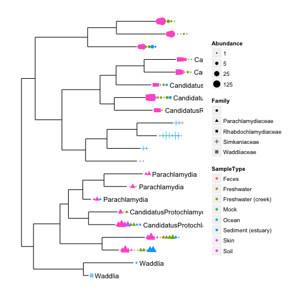

```r
(p <- plot_tree(GP.chl, color = "SampleType", shape = "Family", label.tips = "Genus",
    size = "abundance"))
```

Phylogenetic tree representation of the Chlamydiae species in the microbiome samples of the “Global Patterns” dataset \cite{Caporaso15032011}. [fig:treeplot]

## Exploratory bar plots

[sec:barplots] In the following example we use the included “enterotype”  
dataset \cite{Arumugam:2011fk}.

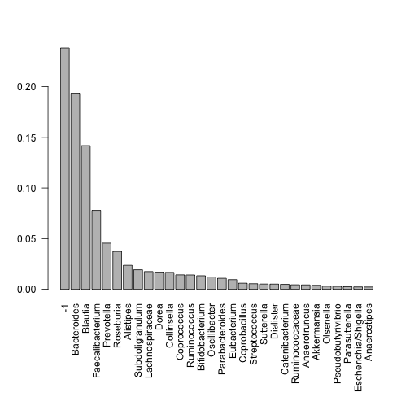

```r
data(enterotype)
par(mar = c(10, 4, 4, 2) + 0.1)  # make more room on bottom margin
N <- 30
barplot(sort(speciesSums(enterotype), TRUE)[1:N]/nsamples(enterotype),
    las = 2)
```

We start with a simple rank-abundance barplot, using the cumulative  
fractional abundance of each OTU in the dataset. In the enterotype  
dataset, the available published data are simplified as sample-wise  
fractional occurrences, rather than counts of individuals[<sup>1],</sup> and OTUs  
are clustered/labeled at the genus level, but no other taxonomic  
assignment is available. For the barplot in Figure [fig:abundbarplot],  
we further normalize by the total number of samples (280).

[htbp]

[figure not shown]

An example exploratory  
barplot using base R graphics and the speciesSums and nsamples  
functions. [fig:abundbarplot]

Note that this first barplot is clipped at the 30th OTU. This was chosen  
because nspecies(enterotype) = 553 OTUs would not be legible on the  
plot. As you can see, the relative abundances have decreased  
dramatically by the 10th-ranked OTU.

So what are these OTUs? In the enterotype dataset, only a single  
taxonomic rank type is present:

```r
rank.names(enterotype)
```

```
## [1] "Genus"
```

This means the OTUs in this dataset have been grouped at the level of  
genera, and no other taxonomic grouping/transformation is possible  
without additional information (like might be present in a phylogenetic  
tree, or with further taxonomic classification analysis).

We need to know which taxonomic rank classifiers, if any, we have  
available to specify in the second barplot function in this example,  
plot_taxa_bar(). We have already observed how quickly the abundance  
decreases with rank, so wo we will subset the enterotype dataset to the  
most abundant N taxa in order to make the barplot legible on this page.

```r
TopNOTUs <- names(sort(speciesSums(enterotype), TRUE)[1:10])
ent10 <- prune_species(TopNOTUs, enterotype)
print(ent10)
```

```
## phyloseq-class experiment-level object
## OTU Table:          [10 species and 280 samples]
##                      species are rows
## Sample Data:         [280 samples by 9 sample variables]:
## Taxonomy Table:     [10 species by 1 taxonomic ranks]:
```

Note also that there are 280 samples in this dataset, and so a remaining  
challenge is to consolidate these samples into meaningful groups. A good  
place to look is the available sample variables, which in most cases  
will carry more “meaning” than the sample names alone.

```r
sample.variables(ent10)
```

```
## [1] "Enterotype"     "Sample_ID"      "SeqTech"        "SampleID"
## [5] "Project"        "Nationality"    "Gender"         "Age"
## [9] "ClinicalStatus"
```

The parameters to plot_taxa_bar in the following code-chunk were  
chosen after various trials. We suggest that you also try different  
parameter settings while you’re exploring different features of the  
data. In addition to the variables names of sampleData, the  
plot_taxa_bar() function recognizes a special parameter name  
“TaxaGroup”, which is not (should not be) a sample variable name in  
sampleData(enterotype), but instead indicates that the particular  
graphic parameter should group values by the taxanomic rank specified in  
the taxavec argument. In this example we have also elected to separate  
the samples by “facets” (separate, adjacent sub-plots) according to the  
enterotype to which they have been assigned. Within each enterotype  
facet, the samples are further separated by sequencing technology, and  
the genera is indicated by fill color. Multiple samples having the same  
enterotype designation and sequencing technology are plotted  
side-by-side as separate bars.

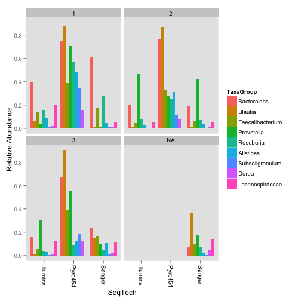

```r
(p <- plot_taxa_bar(ent10, "Genus", x = "SeqTech", fill = "TaxaGroup") +
    facet_wrap(~Enterotype))
```

[htbp]

[figure not shown]

width=1.0 An example  
exploratory barplot using the plot_taxa_bar() function. In this case  
we have faceted the samples according to their assigned Enterotype. The  
small subset of samples in the dataset that do not have an assigned  
Enterotype are shown in the NA panel. Within each Enterotype facet, the  
samples are further separated by sequencing technology, and each genera  
is shaded a different color. Multiple samples from the same Enterotype  
and sequencing technology are plotted side-by-side as separate bars  
(dodged). [fig:barplot]

# Exploratory analysis and graphics

[sec:analysisplots]

## Exploratory Heat Map

[sec:heatmap] As the number of taxa in a dataset gets very large, the  
ability to effectively display all of the elements of the data becomes  
compromised, and a heatmap representation is no exception. It can also  
be time-consuming to render. To address both these issues, we show an  
example in which we have subsetted the Global Patterns dataset to a  
manageable portion, in this case, the Crenarchaeota phylum.

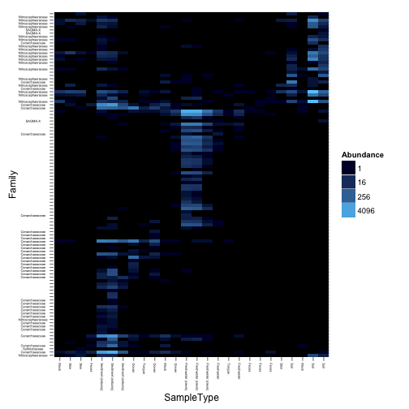

```r
data("GlobalPatterns")
gpac <- subset_species(GlobalPatterns, Phylum == "Crenarchaeota")
(p <- plot_heatmap(gpac, "NMDS", "bray", "SampleType", "Family"))
```

Note that it is possible to order the sample/species indices by any of  
the ordination methods supported in the ordinate function; and also that  
the color scheme can be modified with additional arguments. For  
additional details and examples, try the function-level documentation in  
the phyloseq-package itself, or the wiki-page showing detailed code/plot  
examples for heat maps at:

https://github.com/joey711/phyloseq/wiki/plot_heatmap.

[htbp]

[figure not shown]

Heat map  
representation of the Crenarchaeota phylum abundance pattern across  
different sample types in the Global Patterns dataset. [fig:heatmap]

## Microbiome Network Representation

[sec:network] Continuing with the enterotype dataset, here are some  
examples for creating a custom network representation of the  
relationship between microbiome samples in an experiment. This relies  
heavily on the igraph and ggplot2 packages to create a network display  
of the “connectedness” of samples according to some user-provided  
ecological similarity. By default, the position of points (samples) are  
determined using an algorithm that optimizes the clarity of the display  
of network “edges”, but the spatial position of points does not imply  
any continuous similarity information like would be the case in an  
ordination. In this example, the default dissimilarity index was used  
(Jaccard, co-occurrence), with a maximum distance of 0.3 required to  
create an edge. Any function that can operate on phyloseq-objects and  
return a sample-wise distance can be provided as the dist.fun argument,  
or a character string of the name of the distance function already  
supported in phyloseq. Other distances may result in very different  
clustering, and this is a choice that should be understood and not taken  
too lightly, although there is little harm in trying many different  
distances.

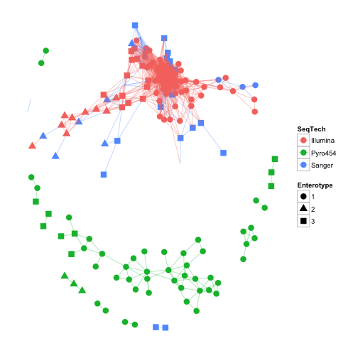

```r
data(enterotype)
ig <- make_network(enterotype, max.dist = 0.3)
(p <- plot_network(ig, enterotype, color = "SeqTech", shape = "Enterotype",
    line_weight = 0.4, label = NULL))
```

Interestingly, at this level of analysis and parameter-settings the two  
major sub-graphs appear to be best explained by the sequencing  
technology and not the subject enterotype (Figure [fig:makenetwork]),  
suggesting that the choice of sequencing technology has a major effect  
on the microbial community one can observe. This seems to differ  
somewhat with the inferences described in the “enterotype”  
article \cite{Arumugam:2011fk}. However, there could be some confounding  
or hidden variables that might also explain this phenomenon, and the  
well-known differences in the sequence totals between the technologies  
may also be an important factor. Furthermore, since this is clearly an  
experimental artifact (and they were including data from multiple  
studies that were not orginally planned for this purpose), it may be  
that the enterotype observation can also be shown in a network analysis  
of this data after removing the effect of sequencing technology and  
related sequencing effort. Such an effort would be interesting to show  
here, but is not yet included.

[htbp]

[figure not shown]

Network  
representation of the relationship between microbiome samples in the  
“Enterotype” dataset \cite{Arumugam:2011fk}. [fig:makenetwork]

## Ordination Methods

[sec:ordination] Ordination methods can be a useful tool for exploring  
complex phylogenetic sequencing data, particularly when the hypothesized  
structure of the data is poorly defined (or there isn’t a hypothesis).  
The phyloseq package provides some useful tools for performing  
ordinations and plotting their results, via the ordinate() and  
plot_ordination() functions, respectively. Although there are many  
options and methods supported, a first-step will probably look something  
like the following:

```
my.physeq <- import("Biom", BIOMfilename="myBiomFile.biom")
my.ord    <- ordinate(my.physeq)
plot_ordination(my.physeq, my.ord, color="myFavoriteVarible")
```

It is probably a good idea to read the documentation for these two  
functions, as they also provide links to related functions and  
additional examples you can try immediately on your own machine.

```
?import
?ordinate
?distance
?plotordination
```

### Principal Coordinates Analysis (PCoA)

The following reproduces the unweighted UniFrac distance calculation on  
the full dataset. Note that this calculation can take a long time  
because of the large number of OTUs. Parallelization is recommended for  
large datasets, typically if they are as large as GlobalPatterns, or  
larger. For details on parallelization, see the details section and  
examples in the UniFrac() documentation, and also the page dedicated to  
the topic on the phyloseq-wiki:

https://github.com/joey711/phyloseq/wiki/Fast-Parallel-UniFrac

```r
data(GlobalPatterns)
### Do note eval GPUF <- UniFrac(GlobalPatterns)
load("Unweighted_UniFrac.RData")
```

```
## Error: cannot open the connection
```

```r
GloPa.pcoa <- pcoa(GPUF)
```

```
## Error: object 'GPUF' not found
```

```r
barplot(GloPa.pcoa$values$Relative_eig)
```

```
## Error: object 'GloPa.pcoa' not found
```

[output not shown]

```r
(p12 <- plot_ordination(GlobalPatterns, GloPa.pcoa, "samples", color = "SampleType") +
    geom_line() + geom_point(size = 5) + scale_colour_hue(guide = "none"))
```

```
## Error: object 'GloPa.pcoa' not found
```

```r
(p13 <- plot_ordination(GlobalPatterns, GloPa.pcoa, "samples", axes = c(1,
    3), color = "SampleType") + geom_line() + geom_point(size = 5))
```

```
## Error: object 'GloPa.pcoa' not found
```

### non-metric Multi-Dimensional Scaling (NMDS)

[sec:NMDS] We repeat the previous example, but instead using non-metric  
multidimensional scaling (NMDS - metaMDS()) limited to just two  
dimensions. This approach limits the amount of residual distance “not  
shown” in the first two (or three) axes, but forefeits some mathematical  
properties and does not always converge within the specified number of  
axes.

```r
data(GlobalPatterns)
load("Unweighted_UniFrac.RData")  # reloads GPUF variable
```

```
## Error: cannot open the connection
```

```r
GP.NMDS <- metaMDS(GPUF, k = 2)  # perform NMDS, set to 2 axes
```

```
## Error: object 'GPUF' not found
```

```r
(p <- plot_ordination(GlobalPatterns, GP.NMDS, "samples", color = "SampleType") +
    geom_line() + geom_point(size = 5))
```

```
## Error: object 'GP.NMDS' not found
```

### Correspondence Analysis (CA)

[sec:CA] In the following section we will show continue our exploration  
of the “GlobalPatterns” dataset using various features of an ordination  
method called Correspondence Analysis. We give special emphasis to  
exploratory interpretations using the biplot, because it provides  
additional information that is not available from PCoA or NMDS.

First, let’s severely subset the number of species for the sake of  
run-time.[<sup>3]</sup>

```r
data(GlobalPatterns)
# Take a subset of the GP dataset, top 200 species
topsp <- names(sort(speciesSums(GlobalPatterns), TRUE)[1:200])
GP <- prune_species(topsp, GlobalPatterns)
# Subset further to top 5 phyla, among the top 200 OTUs.
top5ph <- sort(tapply(speciesSums(GP), taxTab(GP)[, "Phylum"], sum),
    decreasing = TRUE)[1:5]
GP <- subset_species(GP, Phylum %in% names(top5ph))
# Re-add human variable to sample data:
sampleData(GP)$human <- factor(human)
```

```
## Error: object 'human' not found
```

Now perform the correspondence analysis.

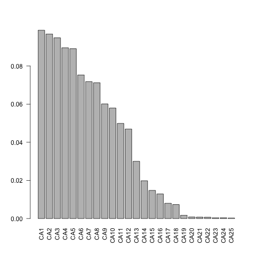

```r
gpca <- ordinate(GP, "CCA")
barplot(gpca$CA$eig/sum(gpca$CA$eig), las = 2)
```

[htbp]

[figure not shown]

The correspondence analysis  
(CA) scree plot of the “Global Patterns”  
dataset \cite{Caporaso15032011}. [fig:GPCAscree]

Now let’s investigate how the samples behave on the first few CA axes.

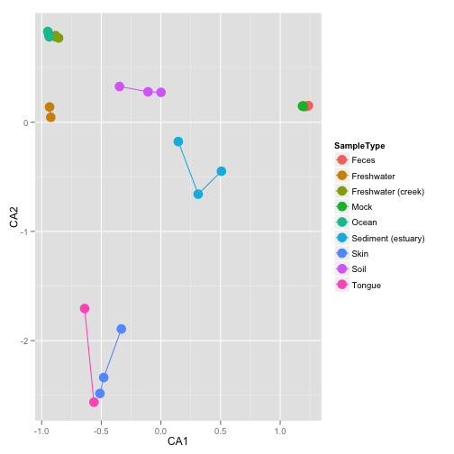

```r
(p12 <- plot_ordination(GP, gpca, "samples", color = "SampleType") +
    geom_line() + geom_point(size = 5))
```

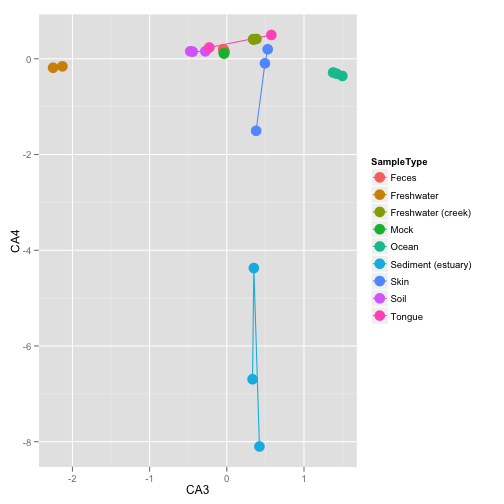

[figure not shown]

```r
(p34 <- plot_ordination(GP, gpca, "samples", axes = c(3, 4), color = "SampleType") +
    geom_line() + geom_point(size = 5))
```

[htbp] [Axes 1, 2][fig:sub:GPCA12]

[figure not shown]

[Axes 3, 4][fig:sub:GPCA34]

[figure not shown]

width=1.0  
First 4 axes of Correspondence Analysis (CA) of the “Global Patterns”  
dataset \cite{Caporaso15032011}. [fig:GPCA]

A clear feature of these plots is that the feces and mock communities  
cluster tightly together, far away from all other samples on the first  
axis (CA1) in Fig. [fig:sub:GPCA12]. The skin and tongue samples  
separate similarly, but on the second axis. Taken together, it appears  
that the first two axes are best explained by the separation of  
human-associated “environments” from the other non-human environments in  
the dataset, with a secondary separation of tongue and skin samples from  
feces.

We will now investigate further this top-level structure of the data,  
using an additional feature of correspondence analysis that allows us to  
compare the relative contributions of individual taxa on the same  
graphical space: the “biplot”. However, because we just displayed the  
position of samples in the ordination and there are often many thousands  
of OTUs, we will focus on creating an interpretable plot of the OTUs.  
For creating graphics that combine the two plots, try the “biplot” or  
“split” option for type in plot_ordination().

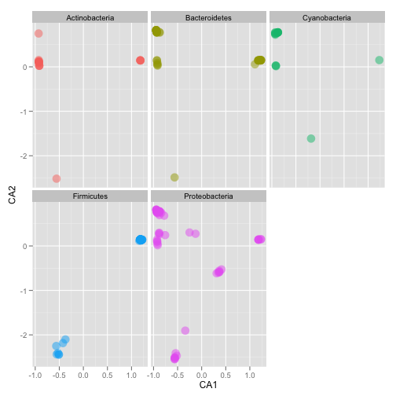

```r
p1 <- plot_ordination(GP, gpca, "species", color = "Phylum")
(p1 <- ggplot(p1$data, p1$mapping) + geom_point(size = 5, alpha = 0.5) +
    facet_wrap(~Phylum) + scale_colour_hue(guide = "none"))
```

[htbp]

[figure not shown]

Species plot of the  
“Global Patterns” correspondence analysis first two axes, with each  
phylum on a different panel (“facet”). Only the most abundant 5 phyla  
among the most abundant 200 taxa (cumulative, all samples) are included.  
Arbitrary reduction, for computational efficiency of example.  
[fig:GPCAspecplot]

Let’s try drawing Fig [fig:GPCAspecplot] again, only this time  
summarizing the species points as a 2D density estimate, without any  
individual points.

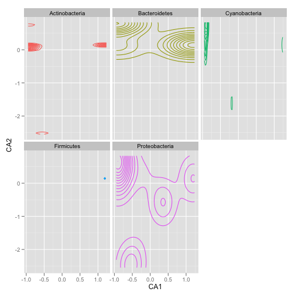

```r
(p3 <- ggplot(p1$data, p1$mapping) + geom_density2d() + facet_wrap(~Phylum) +
    scale_colour_hue(guide = "none"))
```

Redrawn Fig. [fig:GPCAspecplot], which is severely overplotted, as a  
2-dimensional species-density topographic map, faceted in the same way.  
[fig:GPCAspecplotTopo]

Figs [fig:GPCAspecplot] and [fig:GPCAspecplotTopo] reveal some useful  
patterns and interesting outliers, but what if we want a complete  
summary of how each phylum is represented along each axis? The following  
code is a way to show this using boxplots, while still avoiding the  
occlusion problem (points layered on top of each other), and also  
conveying some useful information about the pattern of taxa that  
contribute to the separation of human-associated samples from the other  
sample types. It re-uses the data that was stored in the ggplot2 plot  
object created in the previous figure, p, and creates a new boxlot  
graphical summary of the positions of each phylum  
(Fig [fig:GPCAjitter]).

```r
library("reshape")
```

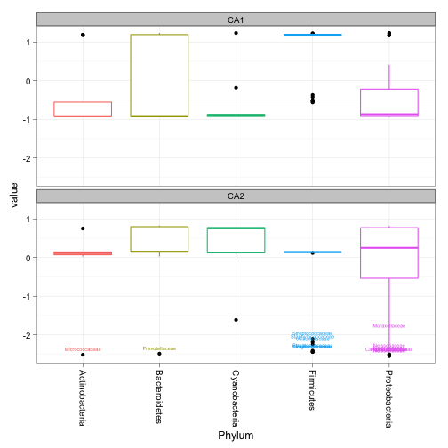

```r
# Melt the species-data.frame, DF, to facet each CA axis separately
mdf <- melt(p1$data[, c("CA1", "CA2", "Phylum", "Family", "Genus")],
    id = c("Phylum", "Family", "Genus"))
# Select some special outliers for labelling
LF <- subset(mdf, variable == "CA2" & value < -1)
# build plot: boxplot summaries of each CA-axis, with labels
p <- ggplot(mdf, aes(Phylum, value, color = Phylum)) + geom_boxplot() +
    facet_wrap(~variable, 2) + scale_colour_hue(guide = "none") + theme_bw() +
    opts(axis.text.x = theme_text(angle = -90, hjust = 0))
# Add the text label layer, and render ggplot graphic
(p <- p + geom_text(aes(Phylum, value + 0.1, color = Phylum, label = Family),
    data = LF, vjust = 0, size = 2))
```

[htbp]

[figure not shown]

Boxplot of taxa (species  
in this case) of the “Global Patterns” CA first two axes,  
shaded/separated by phylum. Through this approach it is much easier to  
see particular species that cluster unusually relative to the rest of  
their phylum, for example the Bacteroidetes species (*Prevotellaceae*  
family) that is positioned most in the negative CA2 direction toward the  
Tongue/Skin samples. [fig:GPCAjitter]

```r
(p <- plot_taxa_bar(GP, "Phylum", NULL, threshold = 0.9, "human",
    "SampleType", facet_formula = TaxaGroup ~ .))
```

```
## Error: object 'human' not found
```

### Double Principle Coordinate Analysis (DPCoA)

Here is a quick example illustrating the use of Double Principal  
Coordinate Analysis (DPCoA \cite{Pavoine2004523}), using the using the  
DPCoA() function in phyloseq, as well as the “biplot” option for  
plot_ordination(). For a description that includes an applied example  
using the “enterotype” dataset and comparison with UniFrac/PCoA, see  
Fukuyama et al \cite{fukuyama2012com}.

```r
GP.dpcoa <- DPCoA(GP)
# GP.dpcoa <- ordinate(GP, 'DPCoA') # Alternative; ordinate() function
pdpcoa <- plot_ordination(GP, GP.dpcoa, type = "biplot", color = "SampleType",
    shape = "Phylum")
shape.fac <- pdpcoa$data[, deparse(pdpcoa$mapping$shape)]
man.shapes <- c(19, 21:25)
names(man.shapes) <- c("samples", levels(shape.fac)[levels(shape.fac) !=
    "samples"])
p2dpcoa <- pdpcoa + scale_shape_manual(values = man.shapes)
```

[htbp]

[figure not shown]

A biplot representation  
of a Double Principal Coordinate Analysis (DPCoA), on a simplified  
version of the “Global Patterns” dataset with only the most abundant 200  
OTUs included. [fig:GPdpcoaBiplot]

## Distance Methods

### distance(): Central Distance Function

Many comparisons of microbiome samples, including the graphical model  
(Section [sec:network]) and the PCoA analysis (Section [sec:PCoA]),  
require a calculation for the relative dissimilarity of one microbial  
community to another, or “distance”. The phyloseq-package provides a  
general “wrapper” function for calculating ecological distance matrices  
between the samples in an experiment.

The function takes a phyloseq-class object and an argument indicating  
the distance type; and it returns a dist-class distance matrix.

```r
data(esophagus)
distance(esophagus)  # Unweighted UniFrac
```

```
##        B      C
## C 0.5176
## D 0.5182 0.5422
```

```r
distance(esophagus, weighted = TRUE)  # weighted UniFrac
```

```
##        B      C
## C 0.2035
## D 0.2603 0.2477
```

```r
distance(esophagus, "jaccard")  # vegdist jaccard
```

```
##        B      C
## C 0.5776
## D 0.6646 0.7427
```

```r
distance(esophagus, "g")  # betadiver method option 'g'
```

```
##        B      C
## C 0.6136
## D 0.6250 0.6078
```

```r
distance("help")
```

```
## Available arguments to methods:
##  [1] "unifrac"    "dpcoa"      "jsd"        "manhattan"  "euclidean"
##  [6] "canberra"   "bray"       "kulczynski" "jaccard"    "gower"
## [11] "altGower"   "morisita"   "horn"       "mountford"  "raup"
## [16] "binomial"   "chao"       "maximum"    "binary"     "minkowski"
## [21] "w"          "-1"         "c"          "wb"         "r"
## [26] "I"          "e"          "t"          "me"         "j"
## [31] "sor"        "m"          "-2"         "co"         "cc"
## [36] "g"          "-3"         "l"          "19"         "hk"
## [41] "rlb"        "sim"        "gl"         "z"
## Please be exact, partial-matching not supported.
## Can alternatively provide a custom distance.
## See:
##  help("distance")
```

### UniFrac and weighted UniFrac

[sec:unifrac] UniFrac is a recently-defined \cite{Lozupone:2005gn} and  
popular distance metric to summarize the difference between pairs of  
ecological communities. All UniFrac variants use a phylogenetic tree of  
the relationship among taxa as central information to calculating the  
distance between two samples/communities. An unweighted UniFrac distance  
matrix only considers the presence/absence of taxa, while weighted  
UniFrac accounts for the relative abundance of taxa as well as their  
phylogenetic distance. Prior to *phyloseq*, a non-parallelized, non-Fast  
implementation of the unweighted UniFrac was available in packages  
(picante::unifrac \cite{Kembel:2010ft}). In the *phyloseq* package we  
provide optionally-parallelized implementations of Fast  
UniFrac \cite{Hamady:2009fk} (both weighted and unweighted, with plans  
for additional UniFrac variants), all of which return a sample-wise  
distance matrix from any phyloseq-class object that contains a  
phylogenetic tree component.

The following is an example calculating the UniFrac distance (both  
weighted and unweighted) matrix using the “esophagus” example dataset:

```r
data(esophagus)
UniFrac(esophagus, weighted = TRUE)
```

```
##        B      C
## C 0.2035
## D 0.2603 0.2477
```

```r
# distance(esophagus, weighted=TRUE) # Alternative using the distance()
# function
UniFrac(esophagus, weighted = FALSE)
```

```
##        B      C
## C 0.5176
## D 0.5182 0.5422
```

```r
# distance(esophagus) # Alternative using the distance() function
round(UniFrac(esophagus, weighted = TRUE), 3)
```

```
##       B     C
## C 0.204
## D 0.260 0.248
```

```r
round(UniFrac(esophagus, weighted = FALSE), 3)
```

```
##       B     C
## C 0.518
## D 0.518 0.542
```

See the wiki-page devoted to details about calculating the UniFrac  
distances for your experiment. In particular, some example run-times are  
provided for comparison, as well as details for initializing a parallel  
“back end” to perform the computation with multiple processor cores  
simultaneously:

https://github.com/joey711/phyloseq/wiki/Fast-Parallel-UniFrac

## Hierarchical Clustering

```r
# (Re)load UniFrac distance matrix and GlobalPatterns data
data(GlobalPatterns)
load("Unweighted_UniFrac.RData")  # reloads GPUF variable
```

```
## Error: cannot open the connection
```

```r
# Manually define color-shading vector based on sample type.
colorScale <- rainbow(length(levels(getVariable(GlobalPatterns, "SampleType"))))
cols <- colorScale[getVariable(GlobalPatterns, "SampleType")]
GP.tip.labels <- as(getVariable(GlobalPatterns, "SampleType"), "character")
GP.hclust <- hclust(GPUF, method = "average")
```

```
## Error: object 'GPUF' not found
```

Plot the hierarchical clustering results as a dendrogram, after first  
converting the hclust-class object to phylo-class tree using the  
as.phylo() function.

```r
plot(as.phylo(GP.hclust), show.tip.label = TRUE, tip.color = "white")
```

```
## Error: object 'GP.hclust' not found
```

```r
tiplabels(GP.tip.labels, col = cols, frame = "none", adj = -0.05,
    cex = 0.7)
```

```
## Error: object 'last_plot.phylo' not found
```

Create an alternative plot, using the Jaccard distance and  
complete-linkage clustering (the default) instead of UPGMA.

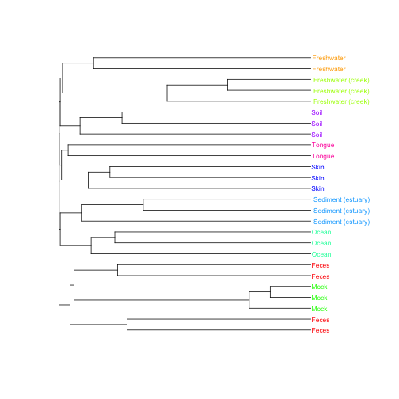

```r
jaccCLC <- hclust(distance(GlobalPatterns, "jaccard"))
plot(as.phylo(jaccCLC), show.tip.label = TRUE, tip.color = "white")
tiplabels(GP.tip.labels, col = cols, frame = "none", adj = -0.05,
    cex = 0.7)
```

# Validation

## Multiple Inference Correction

[sec:multtest] The *phyloseq* package includes support for significance  
testing with correction for multiple inference. This is particularly  
important when testing for significance of the abundance patterns among  
thousands of microbes (OTUs). This is a common question of phylogenetic  
sequence data, that is, “what is the subset of microbes that  
significantly correlate with a scientifically-interesting sample  
variable”. Although we plan to include support for other types of  
multiple-inference corrected tests, this “which taxa?” test is the only  
directly supported test at the moment.

Our initial implementation of this support is via an extension to the  
mt.maxT() and mt.minP functions in the *multtest*  
package \cite{multtest} (Bioconductor repo). This uses  
permutation-adjusted p-values in a multiple testing procedure that  
provides strong control of the Family-Wise Error Rate (FWER) among the  
taxa being tested. The user specifies a sample-variable among the  
sampleData component, or alternatively provides a sample-wise vector or  
factor that classifies the samples into groups. Additional optional  
parameters can be provided that specify the type of test (“test=”), the  
sidedness of the test (“side=”), as well as some additional  
technical/computational parameters.

In the following example we test whether a particular genera correlates  
with the Enterotype classification of each sample. Note that we have to  
specify an alternate test, test=“f”, because the default test (t-test)  
can only handle up to 2 classes, and there are three enterotype classes.

```r
data(enterotype)
# Filter samples that don't have Enterotype classification.
x <- subset_samples(enterotype, !is.na(Enterotype))
# Calculate the multiple-inference-adjusted P-values
ent.p.table <- mt(x, "Enterotype", test = "f")
```

[output not shown]

```r
print(head(ent.p.table, 10))
```

```
##                       index teststat   rawp   adjp plower
## Prevotella              207  344.733 0.0001 0.0158 0.0001
## Bacteroides             203   85.018 0.0001 0.0158 0.0001
## Blautia                 187   19.526 0.0001 0.0158 0.0001
## Bryantella              503   16.383 0.0001 0.0158 0.0001
## Parabacteroides         205   12.894 0.0001 0.0158 0.0001
## Alistipes               208    8.708 0.0002 0.0301 0.0158
## Bifidobacterium         240    9.294 0.0004 0.0560 0.0430
## Holdemania              201    7.638 0.0009 0.1146 0.1031
## Dorea                   182    7.445 0.0009 0.1146 0.1031
## Phascolarctobacterium   513    7.006 0.0014 0.1695 0.1585
```

For computational efficiency this calculation was run separately, and  
results embedded here. [tab:entmt]

Not surprisingly, *Prevotella* and *Bacteroides* top the list, since  
they were major components of the “Enterotype” classification.

Please also note that we are planning to incorporate other tools from  
*multtest* that would allow for other types of multiple-inference  
correction procedures, for instance, strong control of the False  
Discovery Rate (FDR). These additional options will be made available  
shortly.

# Further Examples

This vignette is limited in size and scope because of constraints on the  
cumulative-size of packages allowed in Bioconductor.

## phyloseq Wiki

For further examples presented in html/wiki format, please see:

https://github.com/joey711/phyloseq/wiki/Graphics-Examples

## phyloseq Vignette Gallery

For additional and/or updated vignettes not present in the official  
Bioconductor release, please see:

https://github.com/joey711/phyloseq/wiki/Vignettes

## phyloseq Feedback

For feature requests, bug reports, and other suggestions and issues,  
please go to:

https://github.com/joey711/phyloseq/issues

[<sup>1]:</sup> Unfortunate, as this means we lose information about the total  
number of reads and associated confidences, ability to do more  
sophisticated richness estimates, etc. For example, knowing that we  
observed 1 sequence read of a species out of 100 total reads means  
something very different from observing 10,000 reads out of  
1,000,000 total.

[<sup>2]:</sup> This is also sometimes referred to as “Multi-Dimensional Scaling”,  
or “MDS”

[<sup>3]:</sup> This is for illustration purposes only, do not repeat unless you  
are very sure you have a good reason for doing this.